# Primary School Data

Anuj Verma

October 14, 2017

```r
library(intergraph)
library(mcclust)
library(GGally)
library(network)
library(latticeExtra)
library(dplyr)
library(ergm)
library(sand)
library(ggplot2)

#set default theme for all plots
theme_set(theme_classic()) #set theme for plots
```

## Read graphs for Day1 and Day2

```r
path <- "/Users/Gurpreet/Documents/Coding practices/R"
setwd(path)
ps1 <- read.graph("sp_data_school_day_1.graphml", format = "graphml")
ps2 <- read.graph("sp_data_school_day_2.graphml", format = "graphml")
```

## Summary of Day1 and Day2 graphs

```r
summary(ps1)
```

```
## IGRAPH 005d2cb U-W- 236 5899 --
## + attr: label (v/c), r (v/n), g (v/n), b (v/n), x (v/n), y (v/n),
## | size (v/n), classname (v/c), gender (v/c), id (v/c), edgelabel
## | (e/c), weight (e/n), edgeid (e/c), count (e/n), duration (e/n)
```

```r
summary(ps2)
```

```
## IGRAPH 0066a4a U-W- 238 5539 --
## + attr: label (v/c), r (v/n), g (v/n), b (v/n), x (v/n), y (v/n),
## | size (v/n), classname (v/c), gender (v/c), id (v/c), edgelabel
## | (e/c), weight (e/n), edgeid (e/c), count (e/n), duration (e/n)
```

## Create grades 1-5 for students

Create new vertex attribute `grade` based on the current `classname` attribute. Students are assigned to grades 1-5 and teachers are assigned to grade 6.

```r
#ps1
#create grades 1,2,3,4,5 for students and grade 6 for teachers
classtable <- data.frame(section = c('1A','1B','2A','2B','3A','3B','4A','4B','5A','5B','Teachers'),
                         grade = c(1,1,2,2,3,3,4,4,5,5,6))
ps1.df <- data.frame(id = V(ps1)$id,section=V(ps1)$classname)

#inner join
ps1.df <- inner_join(ps1.df,classtable, by = 'section')
#create a vertex attribute 'grade' for graph
ps1 <- set_vertex_attr(ps1,'grade',index = V(ps1),value = ps1.df$grade)

summary(ps1)
```

```
## IGRAPH 005d2cb U-W- 236 5899 --
## + attr: label (v/c), r (v/n), g (v/n), b (v/n), x (v/n), y (v/n),
## | size (v/n), classname (v/c), gender (v/c), id (v/c), grade
## | (v/n), edgelabel (e/c), weight (e/n), edgeid (e/c), count (e/n),
## | duration (e/n)
```

```r
#ps2
#create grades 1,2,3,4,5 for students and grade 6 for teachers
ps2.df <- data.frame(id = V(ps2)$id,section=V(ps2)$classname)

#inner join
ps2.df <- inner_join(ps2.df,classtable, by = 'section')

#create a vertex attribute 'grade' for graph
ps2 <- set_vertex_attr(ps2,'grade',index = V(ps2),value = ps2.df$grade)

summary(ps2)
```

```
## IGRAPH 0066a4a U-W- 238 5539 --
## + attr: label (v/c), r (v/n), g (v/n), b (v/n), x (v/n), y (v/n),
## | size (v/n), classname (v/c), gender (v/c), id (v/c), grade
## | (v/n), edgelabel (e/c), weight (e/n), edgeid (e/c), count (e/n),
## | duration (e/n)
```

## Log-Log plot for Contact Duration comparison of Day 1 and Day 2

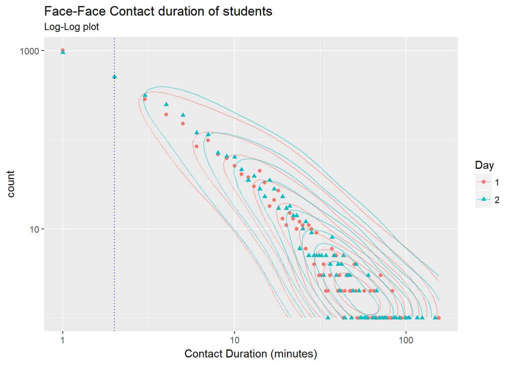

```r
#Distribution for contact duration
#day 1
duration1 <- as.integer((E(ps1)$duration)/60)

t1 <- tabulate(duration1)
t1.df <- data.frame(duration = seq(1,length(t1)),count = t1, Day='1')
t1.df <- t1.df[t1.df$count!=0,]

#day 2
duration2 <- as.integer((E(ps2)$duration)/60)

t2 <- tabulate(duration2)
t2.df <- data.frame(duration = seq(1,length(t2)),count=t2, Day = '2')
t2.df <- t2.df[t2.df$count!=0,]

t.df <- rbind(t1.df,t2.df)

p <- ggplot(data=t.df,aes(x=duration, y=count,color = Day))
p <- p + geom_point(aes(shape = Day)) + geom_vline(xintercept = 2, linetype = 'dotted', color='blue')
p <- p + geom_density_2d(alpha = 0.5)
p <- p + scale_x_log10('Contact Duration (minutes)') + scale_y_log10() + theme_gray()
p <- p + ggtitle('Face-Face Contact duration of students', subtitle = 'Log-Log plot')
plot(p)
```

## Log-Log plot for Number of contacts made in a day by different pairs of individuals

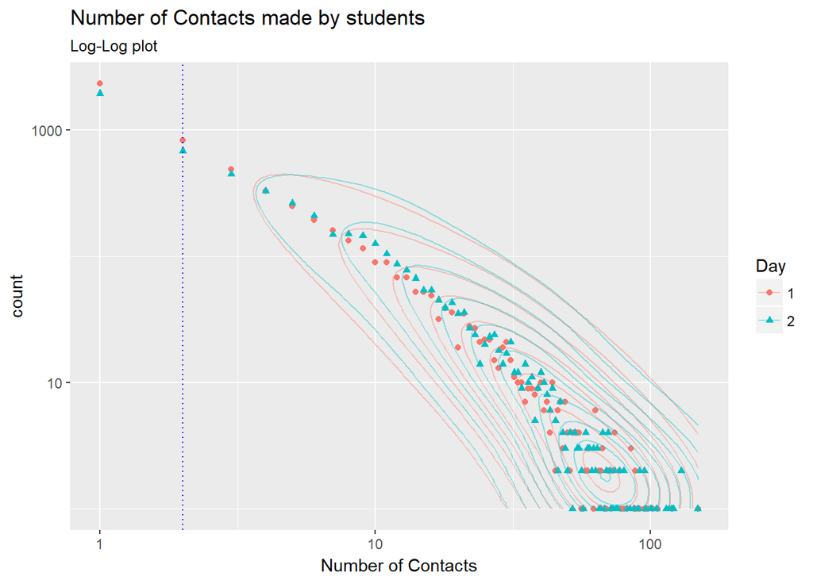

```r
#Distribution for number of contacts in a Day
contact1 <- E(ps1)$count

t1 <- tabulate(contact1)
t1.df <- data.frame(contact = seq(1,length(t1)),count = t1, Day='1')
t1.df <- t1.df[t1.df$count!=0,]

#day 2
contact2 <- E(ps2)$count

t2 <- tabulate(contact2)
t2.df <- data.frame(contact = seq(1,length(t2)),count=t2, Day = '2')
t2.df <- t2.df[t2.df$count!=0,]

t.df <- rbind(t1.df,t2.df)

p <- ggplot(data=t.df,aes(x=contact, y=count,color = Day))
p <- p + geom_point(aes(shape=Day)) + geom_vline(xintercept = 2, linetype = 'dotted', color='blue')
p <- p + geom_density_2d(alpha = 0.4)
p <- p + scale_x_log10('Number of Contacts') + scale_y_log10() + theme_gray()
p <- p + ggtitle('Number of Contacts made by students',subtitle = 'Log-Log plot')
plot(p)
```

```r
#Filter the graph ps1
```

## Network Filtering

```r
#Delete edges with contact duration less than 2mins/120sec
ps1a <- delete_edges(ps1,E(ps1)[E(ps1)$duration <= 120])

#Delete edges with number of contacts less than 2
ps1b <- delete_edges(ps1a,E(ps1a)[E(ps1a)$count <=2 ])

#make contact duration as new edge weight
E(ps1b)$weight <- E(ps1b)$duration

#remove Teachers from our network
day1 <- delete_vertices(ps1b,V(ps1b)[V(ps1b)$classname =='Teachers'])
day1 <- delete_vertices(day1,V(day1)[V(day1)$gender =='Unknown'])

summary(day1) #final graph
```

```
## IGRAPH 032e9a4 U-W- 222 1558 --
## + attr: label (v/c), r (v/n), g (v/n), b (v/n), x (v/n), y (v/n),
## | size (v/n), classname (v/c), gender (v/c), id (v/c), grade
## | (v/n), edgelabel (e/c), weight (e/n), edgeid (e/c), count (e/n),
## | duration (e/n)
```

```r
#Filter the graph ps2
#Delete edges with contact duration less than 2mins/120sec
ps2a <- delete_edges(ps2,E(ps2)[E(ps2)$duration <= 120])

#Delete edges with number of contacts less than 2
ps2b <- delete_edges(ps2a,E(ps2a)[E(ps2a)$count <=2 ])

#make contact duration as new edge weight
E(ps2b)$weight <- E(ps2b)$duration

#remove Teachers from our network
day2 <- delete_vertices(ps2b,V(ps2b)[V(ps2b)$classname =='Teachers'])
day2 <- delete_vertices(day2,V(day2)[V(day2)$gender =='Unknown'])
summary(day2) #final graph
```

```
## IGRAPH 0334553 U-W- 223 1779 --
## + attr: label (v/c), r (v/n), g (v/n), b (v/n), x (v/n), y (v/n),
## | size (v/n), classname (v/c), gender (v/c), id (v/c), grade
## | (v/n), edgelabel (e/c), weight (e/n), edgeid (e/c), count (e/n),
## | duration (e/n)
```

## Save the new networks and create visualizations in gephi

```r
#save graphs
write_graph(day1,'day1_filtered.graphml',format = 'graphml')
write_graph(day1,'day2_filtered.graphml',format = 'graphml')
```

### Day 1

The high degree nodes have larger size than the low degree nodes. The color of nodes represent grades. Pink - 1, green- 2, skyblue-3, darkgray-4, orange-5. The edge weight represents total contact duration between two nodes.

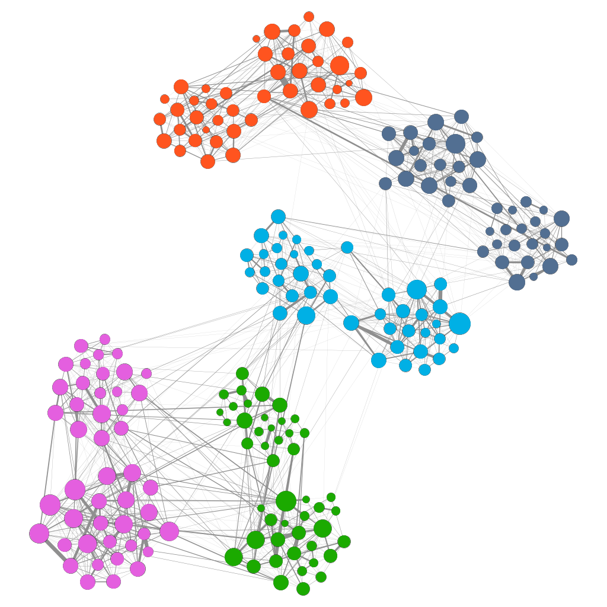

```r
knitr::include_graphics("Visualization_day1.png")
```

### Day 2

The high degree nodes have larger size than the low degree nodes. The color of nodes represent grades. Pink - 1, green- 2, skyblue-3, darkgray-4, orange-5. The edge weight represents total contact duration between two nodes.

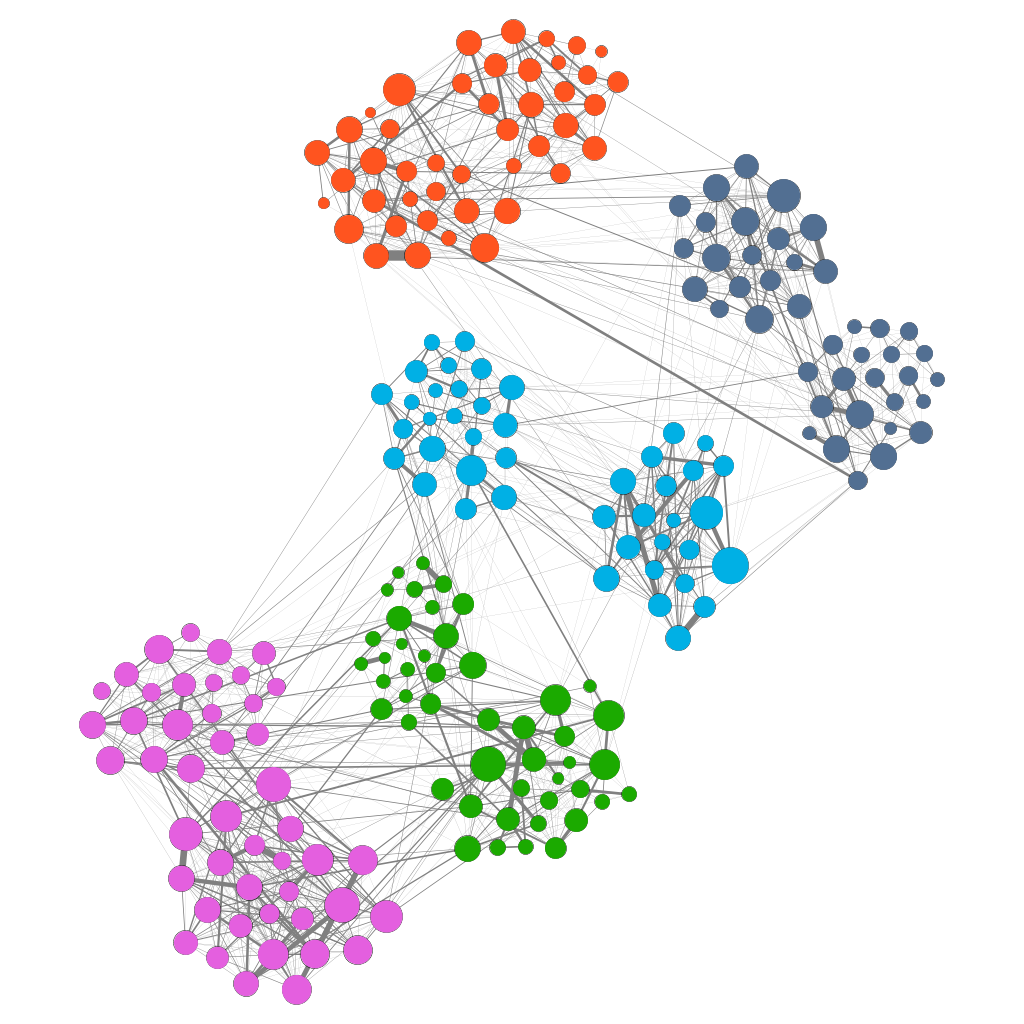

```r
knitr::include_graphics("Visualization_day2.png")
```

## Homophily across the classrooms

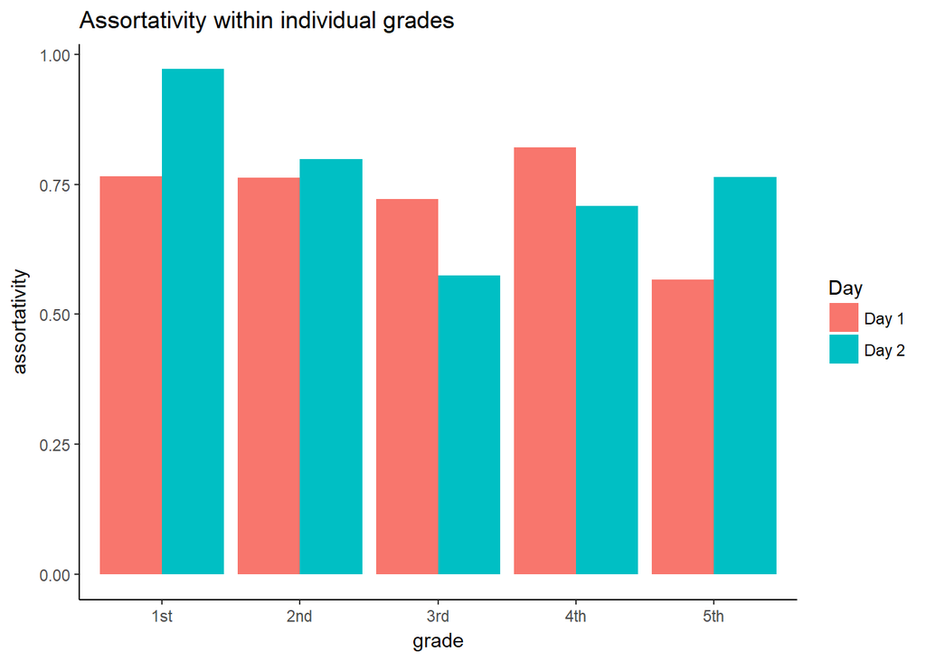

```r
#Calculate assortativity by grades and plot it. day1 vs day2
#extract different grade networks
#day-1
g1 <- which(V(day1)$grade == 1)
day1.g1 <- induced_subgraph(day1,g1)

g2 <- which(V(day1)$grade == 2)
day1.g2 <- induced_subgraph(day1,g2)

g3 <- which(V(day1)$grade == 3)
day1.g3 <- induced_subgraph(day1,g3)

g4 <- which(V(day1)$grade == 4)
day1.g4 <- induced_subgraph(day1,g4)

g5 <- which(V(day1)$grade == 5)
day1.g5 <- induced_subgraph(day1,g5)

#day-2
g1 <- which(V(day2)$grade == 1)
day2.g1 <- induced_subgraph(day2,g1)

g2 <- which(V(day2)$grade == 2)
day2.g2 <- induced_subgraph(day2,g2)

g3 <- which(V(day2)$grade == 3)
day2.g3 <- induced_subgraph(day2,g3)

g4 <- which(V(day2)$grade == 4)
day2.g4 <- induced_subgraph(day2,g4)

g5 <- which(V(day2)$grade == 5)
day2.g5 <- induced_subgraph(day2,g5)

#assortativity by class sections
day1.assor_sect <- c(assortativity_nominal(day1.g1,types = factor(V(day1.g1)$classname)),
                      assortativity_nominal(day1.g2,types = factor(V(day1.g2)$classname)),
                      assortativity_nominal(day1.g3,types = factor(V(day1.g3)$classname)),
                      assortativity_nominal(day1.g4,types = factor(V(day1.g4)$classname)),
                      assortativity_nominal(day1.g5,types = factor(V(day1.g5)$classname)))

day2.assor_sect <- c(assortativity_nominal(day2.g1,types = factor(V(day2.g1)$classname)),
                      assortativity_nominal(day2.g2,types = factor(V(day2.g2)$classname)),
                      assortativity_nominal(day2.g3,types = factor(V(day2.g3)$classname)),
                      assortativity_nominal(day2.g4,types = factor(V(day2.g4)$classname)),
                      assortativity_nominal(day2.g5,types = factor(V(day2.g5)$classname)))

assor_sect.dist1 <- data.frame(grade = c('1st','2nd','3rd','4th','5th'),
                                assortativity= day1.assor_sect, Day='Day 1')
assor_sect.dist2 <- data.frame(grade = c('1st','2nd','3rd','4th','5th'),
                                assortativity= day2.assor_sect, Day='Day 2')

assor_sect.dist <- rbind(assor_sect.dist1,assor_sect.dist2)
#plot
p <- ggplot(data = assor_sect.dist, aes(x = grade,y=assortativity,fill=Day)) +
      geom_bar(stat='identity',position = 'dodge')+
      ggtitle('Assortativity within individual grades')
plot(p)
```

## Homophily across different grades

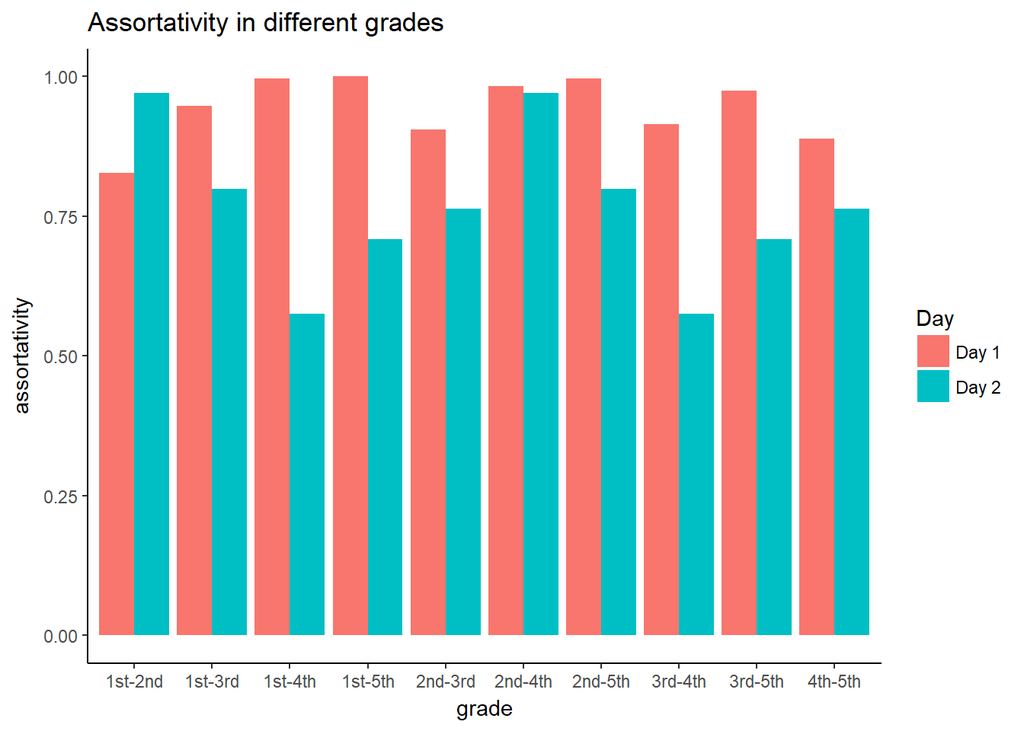

```r
#Inter-grade assortativity
#extract subgraphs from day1
day1.gr12 <- induced_subgraph(day1,which(V(day1)$grade == 1 | V(day1)$grade ==2))
day1.gr13 <- induced_subgraph(day1,which(V(day1)$grade == 1 | V(day1)$grade ==3))
day1.gr14 <- induced_subgraph(day1,which(V(day1)$grade == 1 | V(day1)$grade ==4))
day1.gr15 <- induced_subgraph(day1,which(V(day1)$grade == 1 | V(day1)$grade ==5))
day1.gr23 <- induced_subgraph(day1,which(V(day1)$grade == 2 | V(day1)$grade ==3))
day1.gr24 <- induced_subgraph(day1,which(V(day1)$grade == 2 | V(day1)$grade ==4))
day1.gr25 <- induced_subgraph(day1,which(V(day1)$grade == 2 | V(day1)$grade ==5))
day1.gr34 <- induced_subgraph(day1,which(V(day1)$grade == 3 | V(day1)$grade ==4))
day1.gr35 <- induced_subgraph(day1,which(V(day1)$grade == 3 | V(day1)$grade ==5))
day1.gr45 <- induced_subgraph(day1,which(V(day1)$grade == 4 | V(day1)$grade ==5))

#extract subgraphs from day2
day2.gr12 <- induced_subgraph(day2,which(V(day2)$grade == 1 | V(day2)$grade ==2))
day2.gr13 <- induced_subgraph(day2,which(V(day2)$grade == 1 | V(day2)$grade ==3))
day2.gr14 <- induced_subgraph(day2,which(V(day2)$grade == 1 | V(day2)$grade ==4))
day2.gr15 <- induced_subgraph(day2,which(V(day2)$grade == 1 | V(day2)$grade ==5))
day2.gr23 <- induced_subgraph(day2,which(V(day2)$grade == 2 | V(day2)$grade ==3))
day2.gr24 <- induced_subgraph(day2,which(V(day2)$grade == 2 | V(day2)$grade ==4))
day2.gr25 <- induced_subgraph(day2,which(V(day2)$grade == 2 | V(day2)$grade ==5))
day2.gr34 <- induced_subgraph(day2,which(V(day2)$grade == 3 | V(day2)$grade ==4))
day2.gr35 <- induced_subgraph(day2,which(V(day2)$grade == 3 | V(day2)$grade ==5))
day2.gr45 <- induced_subgraph(day2,which(V(day2)$grade == 4 | V(day2)$grade ==5))

#assortativity by grades
day1.assor_grade <- c(assortativity_nominal(day1.gr12,types = factor(V(day1.gr12)$grade)),
                      assortativity_nominal(day1.gr13,types = factor(V(day1.gr13)$grade)),
                      assortativity_nominal(day1.gr14,types = factor(V(day1.gr14)$grade)),
                      assortativity_nominal(day1.gr15,types = factor(V(day1.gr15)$grade)),
                      assortativity_nominal(day1.gr23,types = factor(V(day1.gr23)$grade)),
                      assortativity_nominal(day1.gr24,types = factor(V(day1.gr24)$grade)),
                      assortativity_nominal(day1.gr25,types = factor(V(day1.gr25)$grade)),
                      assortativity_nominal(day1.gr34,types = factor(V(day1.gr34)$grade)),
                      assortativity_nominal(day1.gr35,types = factor(V(day1.gr35)$grade)),
                      assortativity_nominal(day1.gr45,types = factor(V(day1.gr45)$grade)))

day2.assor_grade <- c(assortativity_nominal(day2.gr12,types = factor(V(day2.gr12)$grade)),
                      assortativity_nominal(day2.gr13,types = factor(V(day2.gr13)$grade)),
                      assortativity_nominal(day2.gr14,types = factor(V(day2.gr14)$grade)),
                      assortativity_nominal(day2.gr15,types = factor(V(day2.gr15)$grade)),
                      assortativity_nominal(day2.gr23,types = factor(V(day2.gr23)$grade)),
                      assortativity_nominal(day2.gr24,types = factor(V(day2.gr24)$grade)),
                      assortativity_nominal(day2.gr25,types = factor(V(day2.gr25)$grade)),
                      assortativity_nominal(day2.gr34,types = factor(V(day2.gr34)$grade)),
                      assortativity_nominal(day2.gr35,types = factor(V(day2.gr35)$grade)),
                      assortativity_nominal(day2.gr45,types = factor(V(day2.gr45)$grade)))

assor_grade.dist1 <- data.frame(grade = c('1st-2nd','1st-3rd','1st-4th','1st-5th','2nd-3rd','2nd-4th','2nd-5th','3rd-4th','3rd-5th','4th-5th'),
                               assortativity= day1.assor_grade, Day='Day 1')
assor_grade.dist2 <- data.frame(grade = c('1st-2nd','1st-3rd','1st-4th','1st-5th','2nd-3rd','2nd-4th','2nd-5th','3rd-4th','3rd-5th','4th-5th'),
                               assortativity= day2.assor_sect, Day='Day 2')

assor_grade.dist <- rbind(assor_grade.dist1,assor_grade.dist2)
#plot
p <- ggplot(data = assor_grade.dist, aes(x = grade,y=assortativity,fill=Day)) +
  geom_bar(stat='identity',position = 'dodge')+
  ggtitle('Assortativity in different grades')
plot(p)
```

## CUG test for Assortativity by gender

```r
#set seed value
set.seed(111089)
#CUG Test of assortativity by gender
source('mycugtest.r')
```

[output not shown]

```r
day1.cug_gendr <- mycugtest(day1,assortativity_nominal,cmode = 'edges',
                            directed = F, types = factor(V(day1)$gender))
print.cug.test(day1.cug_gendr)
```

```
##
## Univariate Conditional Uniform Graph Test
##
## Conditioning Method: edges
## Graph Type:
## Diagonal Used: FALSE
## Replications: 1000
##
## Observed Value: 0.1909448
## Pr(X>=Obs): 0
## Pr(X<=Obs): 1
```

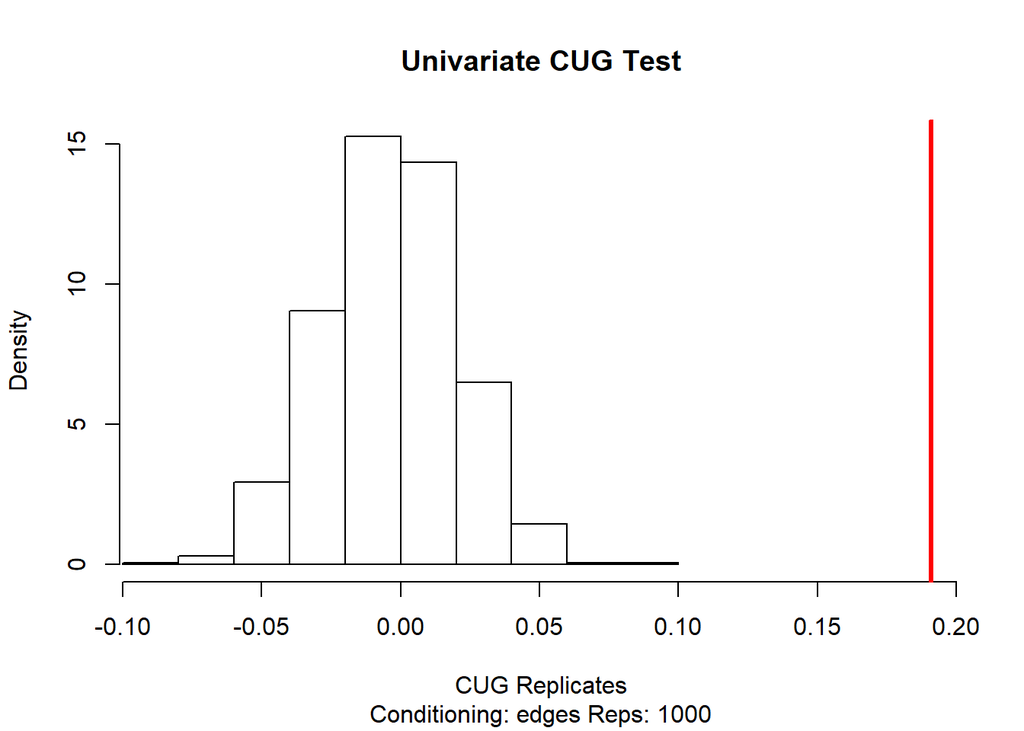

```r
plot.cug.test(day1.cug_gendr)
```

## CUG test for Assortativity by grade

```r
#CUG Test of assortativity by grade
day1.cug_grade <- mycugtest(day1,assortativity_nominal,cmode = 'edges',
                            directed = F,types=factor(V(day1)$grade))
print.cug.test(day1.cug_grade)
```

```
##
## Univariate Conditional Uniform Graph Test
##
## Conditioning Method: edges
## Graph Type:
## Diagonal Used: FALSE
## Replications: 1000
##
## Observed Value: 0.8698987
## Pr(X>=Obs): 0
## Pr(X<=Obs): 1
```

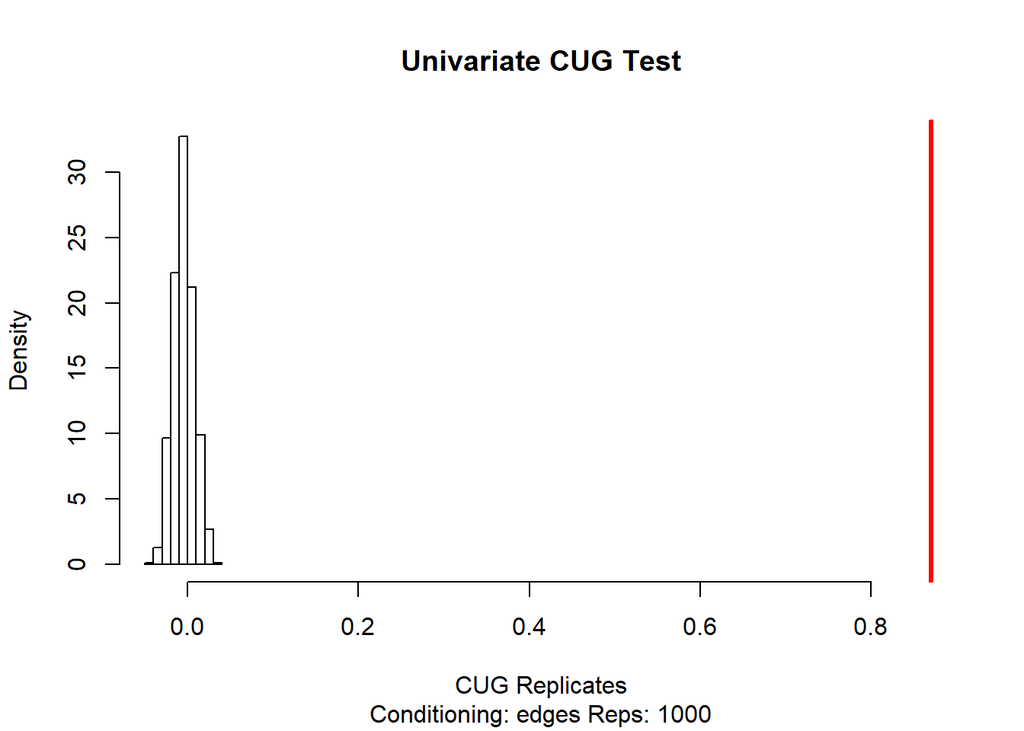

```r
plot.cug.test(day1.cug_grade)
```

## QAP test for Assortativity by gender

```r
#QAP test
source('myqaptest.r')
day1.qap_gender <- myqaptest(day1,assortativity_nominal, directed=F,
                             types = factor(V(day1)$gender))
summary.qaptest(day1.qap_gender)
```

```
##
## QAP Test Results
##
## Estimated p-values:
##  p(f(perm) >= f(d)): 0
##  p(f(perm) <= f(d)): 1
##
## Test Diagnostics:
##  Test Value (f(d)): 0.1909448
##  Replications: 1000
##  Distribution Summary:
##      Min:     -0.06951395
##      1stQ:    -0.02240501
##      Med:     -0.005329769
##      Mean:    -0.004726667
##      3rdQ:    0.01083443
##      Max:     0.08482535
```

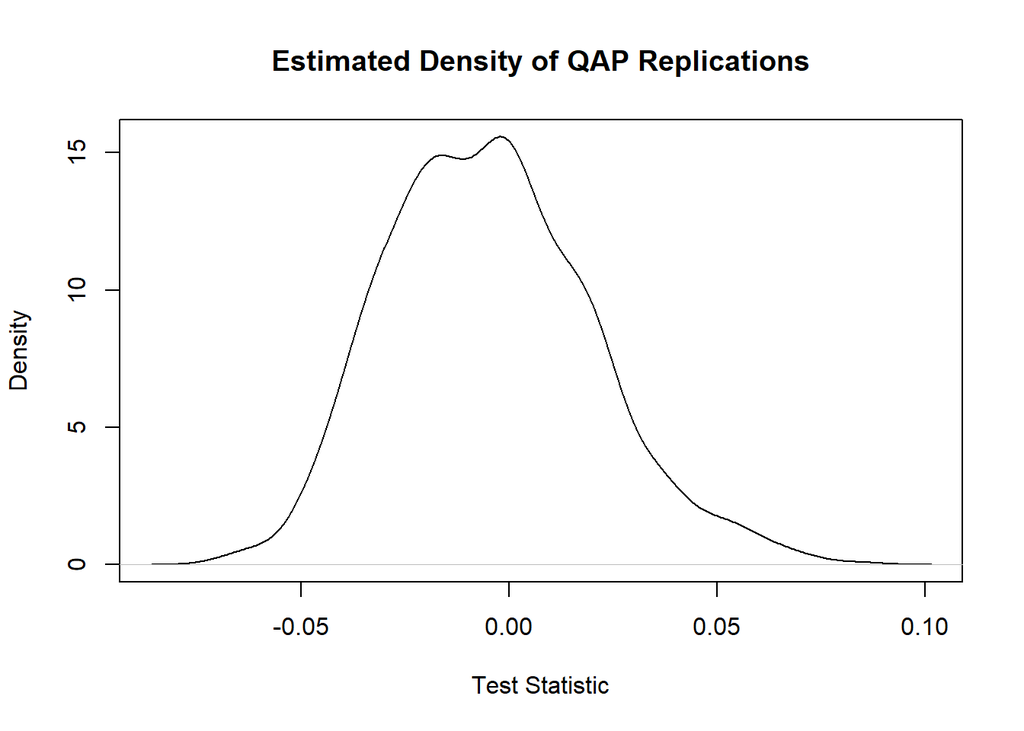

```r
plot.qaptest(day1.qap_gender)
```

## QAP test for Assortativity by grade

```r
day1.qap_grade <- myqaptest(day1,assortativity_nominal, directed=F,
                             types = factor(V(day1)$grade))
summary.qaptest(day1.qap_grade)
```

```
##
## QAP Test Results
##
## Estimated p-values:
##  p(f(perm) >= f(d)): 0
##  p(f(perm) <= f(d)): 1
##
## Test Diagnostics:
##  Test Value (f(d)): 0.8698987
##  Replications: 1000
##  Distribution Summary:
##      Min:     -0.03862413
##      1stQ:    -0.01357898
##      Med:     -0.005417229
##      Mean:    -0.005251706
##      3rdQ:    0.002926195
##      Max:     0.0390363
```

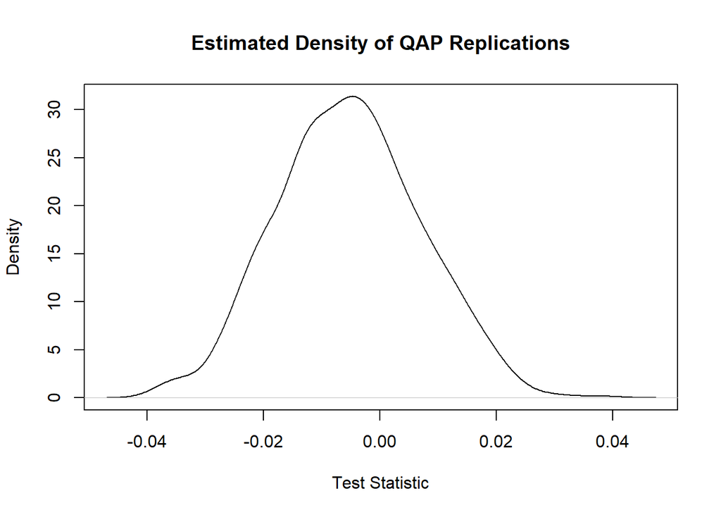

```r
plot.qaptest(day1.qap_grade)
```

## ERGM Models

We are implementing ERGM model on a `grade 1` network which is a very simple version of the network. Due to high computational requirements of this model, it was not possible to run this model to check the homophily within multiple grades.

```r
#ergm models

#First try on very simple network
#grade1-day1
gr1 <- asNetwork(day1.g1)
#grade 1 - day 2
gr1.d2 <- asNetwork(day2.g1)
```

Load all saved ergm models.

```r
#Different models
#gr1.m1 <- ergm(gr1~edges + nodemix('classname',base=3))
#gr1.m1a <- ergm(gr1~edges + gwesp) #failed
#gr1.m2 <- ergm(gr1~edges + nodemix('classname',base=3) + degree(10)) #good model
#gr1.m2a <- ergm(gr1~edges + nodemix('classname',base = 3) + degree(10) + degree(12)) #good model
#gr1.m2b <- ergm(gr1~edges + nodemix('classname',base = 3) + degree(10),
#                control = control.ergm(MCMC.burnin = 100000,MCMC.interval = 10000,MCMC.samplesize = 2048))
#gr1.m3 <- ergm(gr1~edges + nodemix('classname',base = c(1,3)) + degree(10,'gender'))
#gr1.m3a <- ergm(gr1~edges + nodemix('classname',base = c(1,3)) + degree(10,'gender'),
#                control = control.ergm(MCMC.burnin = 100000,MCMC.interval = 10000,MCMC.samplesize = 2048)) #Good model
#gr1.m4 <- ergm(gr1~edges + nodemix('classname',base = c(1,3)) + degree(10,'classname')) #failed
#gr1.m5 <- ergm(gr1~edges + nodemix('classname',base = c(1,3)) + degree(10) + gwesp) #see later

#gender
#gr1.m6 <- ergm(gr1~edges + nodemix('gender', base=c(3)))
#gr1.m7 <- ergm(gr1~edges + nodemix('gender', base=c(1,3))+ degree(10,'gender'))
#gr1.m8 <- ergm(gr1~edges + nodemix('gender',base=c(1,3)) + degree(10,'gender') + gwesp(cutoff=20)) #failed
#gr1.m9 <- ergm(gr1~edges + nodemix('gender',base=c(1,3)) + degree(10,'gender') + gwesp(3:7)) #failed
#gr1.m10 <- ergm(gr1~edges + nodemix('gender',base=c(1,3)) + degree(10,'gender') + gwesp(12)) #failed
#gr1.m11 <- ergm(gr1~edges + nodemix('gender', base = c(1,3))+ degree(10) + concurrent('gender')) #failed
#gr1.m12 <- ergm(gr1~edges + sociality('gender',base=1)) #too many coefficients

#both
#gr1.m13 <- ergm(gr1~edges + nodemix('gender',base = c(1,3)) + nodemix('classname',base = c(1,3)))
#gr1.m14 <- ergm(gr1~edges + nodemix('gender',base = c(1,3)) + nodemix('classname',base = c(1,3)) +
#                  degree(10,'gender')) #good model
#gr1.m15 <- ergm(gr1~edges + nodemix('gender',base = c(1,3)) + nodemix('classname',base = c(1,3)) + degree(10,'gender'),
#                control = control.ergm(MCMC.burnin = 100000,MCMC.interval = 10000,MCMC.samplesize = 2048)) #Failed

#gr1.m16 <- ergm(gr1~edges + nodemix('classname',base=c(3))+ nodematch('gender',diff=T) + degree(10))
#gr1.m16a <- ergm(gr1~edges + nodemix('classname',base=c(3))+ nodematch('gender',diff=T) + degree(10),
#                 control = control.ergm(MCMC.burnin = 100000,MCMC.interval = 15000,MCMC.samplesize = 2048))

load('grade1-day1-models.Rdata')
```

### Model 1: Edges and nodemix classname

1B-1B is considered as base.

```r
#Model1
#gr1.m1 <- ergm(gr1~edges + nodemix('classname',base=3))
summary(gr1.m1)
```

```
##
## ==========================
## Summary of model fit
## ==========================
##
## Formula:   gr1 ~ edges + nodemix("classname", base = 3)
##
## Iterations:  6 out of 20
##
## Monte Carlo MLE Results:
##                     Estimate Std. Error MCMC % p-value
## edges                 0.8473     0.1260      0  <1e-04 ***
## mix.classname.1A.1A  -0.4616     0.1888      0  0.0146 *
## mix.classname.1A.1B  -3.2896     0.2043      0  <1e-04 ***
## ---
## Signif. codes:  0 '***' 0.001 '**' 0.01 '*' 0.05 '.' 0.1 ' ' 1
##
##      Null Deviance: 1434.8  on 1035  degrees of freedom
##  Residual Deviance:  942.7  on 1032  degrees of freedom
##
## AIC: 948.7    BIC: 963.5    (Smaller is better.)
```

#### M1: GOF

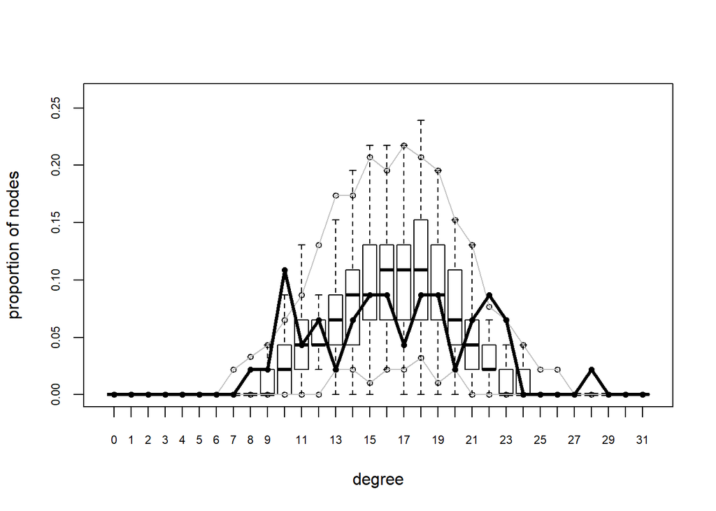

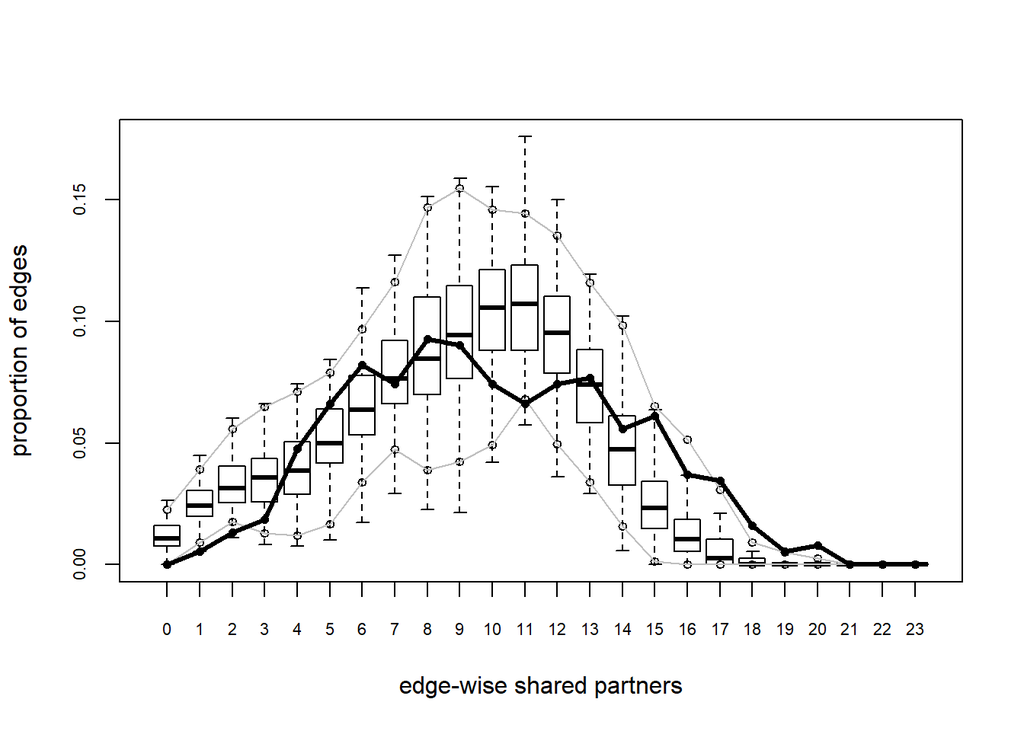

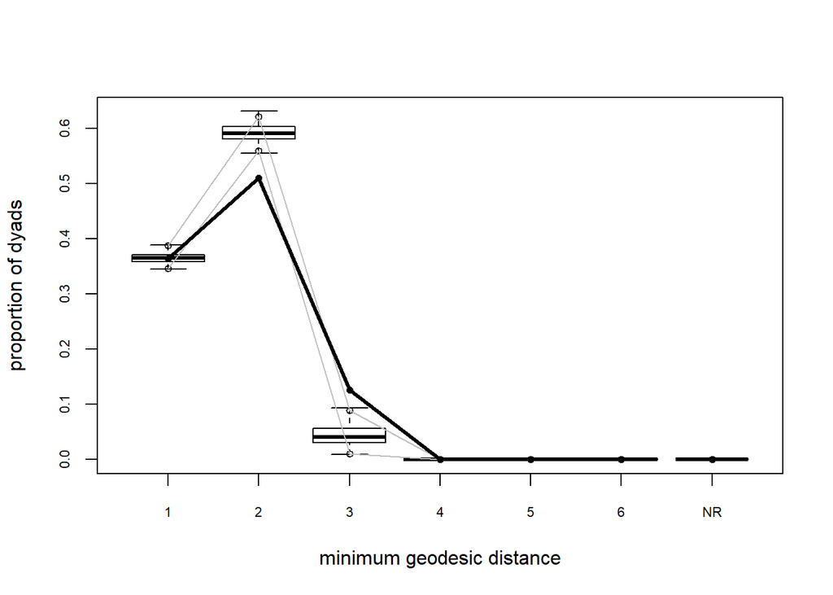

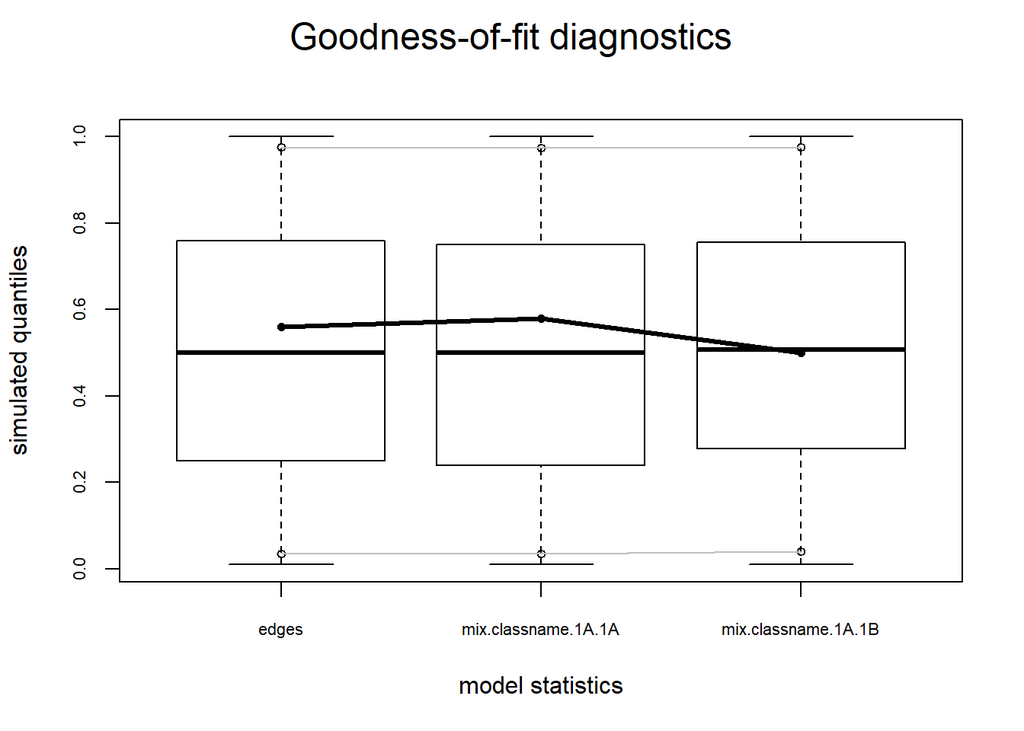

```r
gr1.m1.gof <- gof(gr1.m1)
plot(gr1.m1.gof)
```

### Model 2: Edges, class nodemix and degree

M1 + degree(10)

```r
#Model2
#gr1.m2 <- ergm(gr1~edges + nodemix('classname',base=3) + degree(10))
summary(gr1.m2)
```

```
##
## ==========================
## Summary of model fit
## ==========================
##
## Formula:   gr1 ~ edges + nodemix("classname", base = 3) + degree(10)
##
## Iterations:  2 out of 20
##
## Monte Carlo MLE Results:
##                     Estimate Std. Error MCMC %  p-value
## edges                 0.8612     0.1131      0  < 1e-04 ***
## mix.classname.1A.1A  -0.1415     0.2074      0 0.495128
## mix.classname.1A.1B  -3.1660     0.2026      0  < 1e-04 ***
## degree10              2.4951     0.6480      0 0.000125 ***
## ---
## Signif. codes:  0 '***' 0.001 '**' 0.01 '*' 0.05 '.' 0.1 ' ' 1
##
##      Null Deviance: 1434.8  on 1035  degrees of freedom
##  Residual Deviance:  931.9  on 1031  degrees of freedom
##
## AIC: 939.9    BIC: 959.7    (Smaller is better.)
```

#### M2: GOF

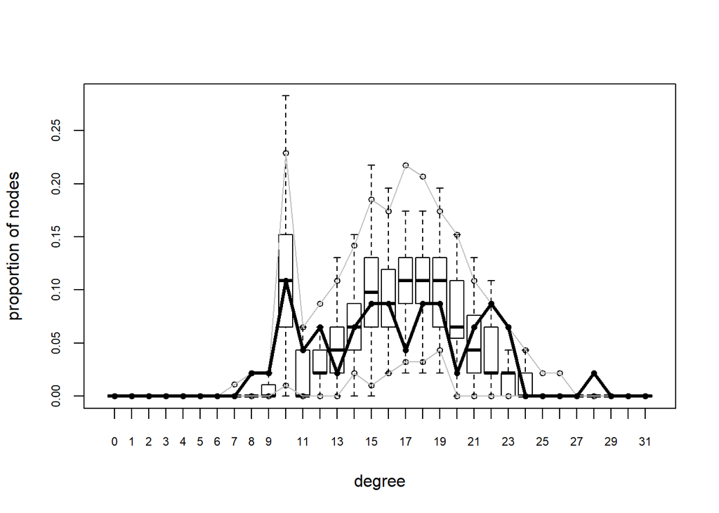

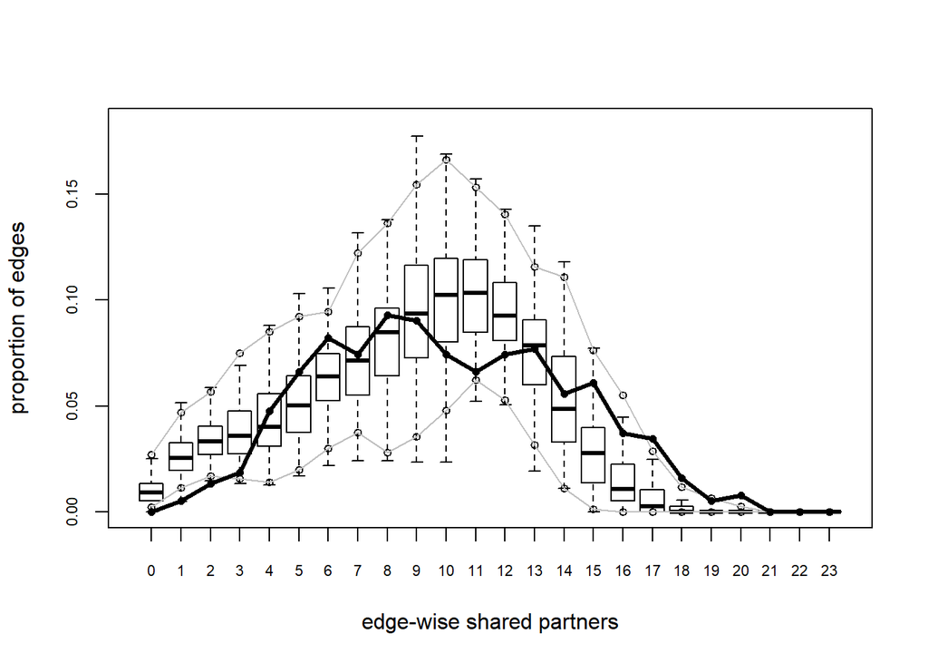

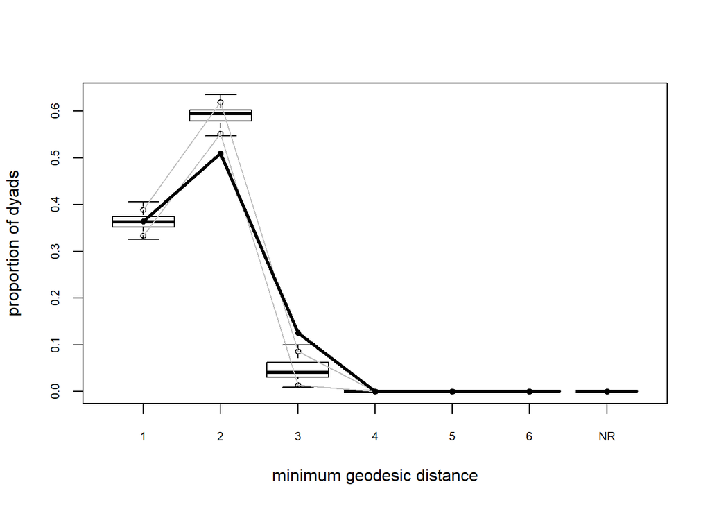

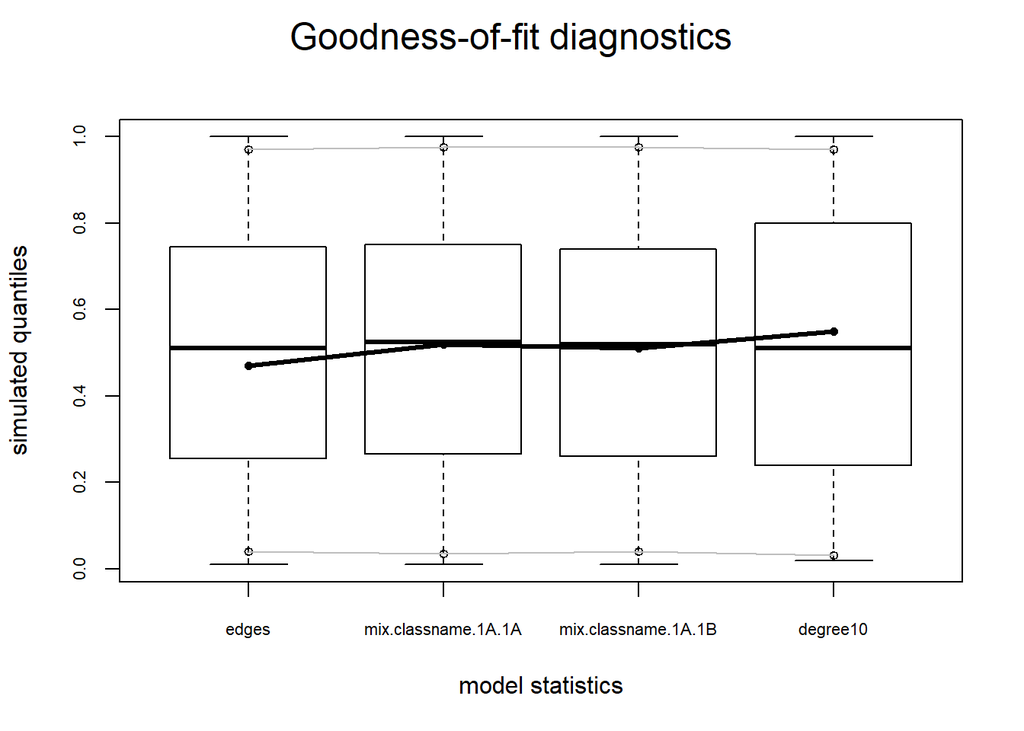

```r
gr1.m2.gof <- gof(gr1.m2)
plot(gr1.m2.gof)
```

#### M2: Diagnostics

```r
mcmc.diagnostics(gr1.m2,center = F)
```

```
## Sample statistics summary:
##
## Iterations = 16384:4209664
## Thinning interval = 1024
## Number of chains = 1
## Sample size per chain = 4096
##
## 1. Empirical mean and standard deviation for each variable,
##    plus standard error of the mean:
##
##                       Mean     SD Naive SE Time-series SE
## edges               365.88 15.783  0.24661         0.5535
## mix.classname.1A.1A 118.37  9.126  0.14259         0.3970
## mix.classname.1A.1B  39.19  6.623  0.10349         0.1602
## degree10              7.44  2.918  0.04559         0.1080
##
## 2. Quantiles for each variable:
##
##                     2.5% 25% 50% 75% 97.5%
## edges                336 355 365 376   399
## mix.classname.1A.1A  102 112 118 124   137
## mix.classname.1A.1B   27  35  39  43    53
## degree10               2   5   7   9    13
##
##
## Sample statistics cross-correlations:
##                          edges mix.classname.1A.1A mix.classname.1A.1B
## edges                1.0000000           0.6970313           0.5948731
## mix.classname.1A.1A  0.6970313           1.0000000           0.2492613
## mix.classname.1A.1B  0.5948731           0.2492613           1.0000000
## degree10            -0.7261579          -0.8053621          -0.4410207
##                       degree10
## edges               -0.7261579
## mix.classname.1A.1A -0.8053621
## mix.classname.1A.1B -0.4410207
## degree10             1.0000000
##
## Sample statistics auto-correlation:
## Chain 1
##              edges mix.classname.1A.1A mix.classname.1A.1B  degree10
```

[output cut: 9 more lines]

```
##
## Fraction in 1st window = 0.1
## Fraction in 2nd window = 0.5
##
##               edges mix.classname.1A.1A mix.classname.1A.1B
##             -1.1716             -1.3810             -0.3545
##            degree10
##              1.6113
##
## Individual P-values (lower = worse):
##               edges mix.classname.1A.1A mix.classname.1A.1B
##           0.2413479           0.1672860           0.7229276
##            degree10
##           0.1071129
## Joint P-value (lower = worse):  0.6727645 .
```

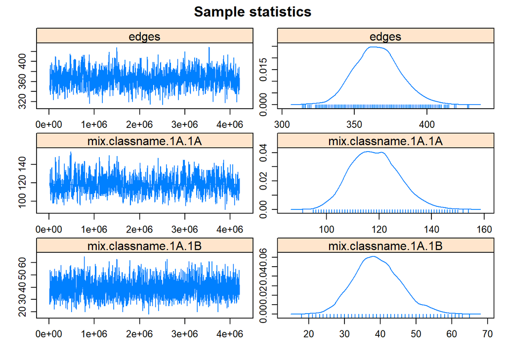

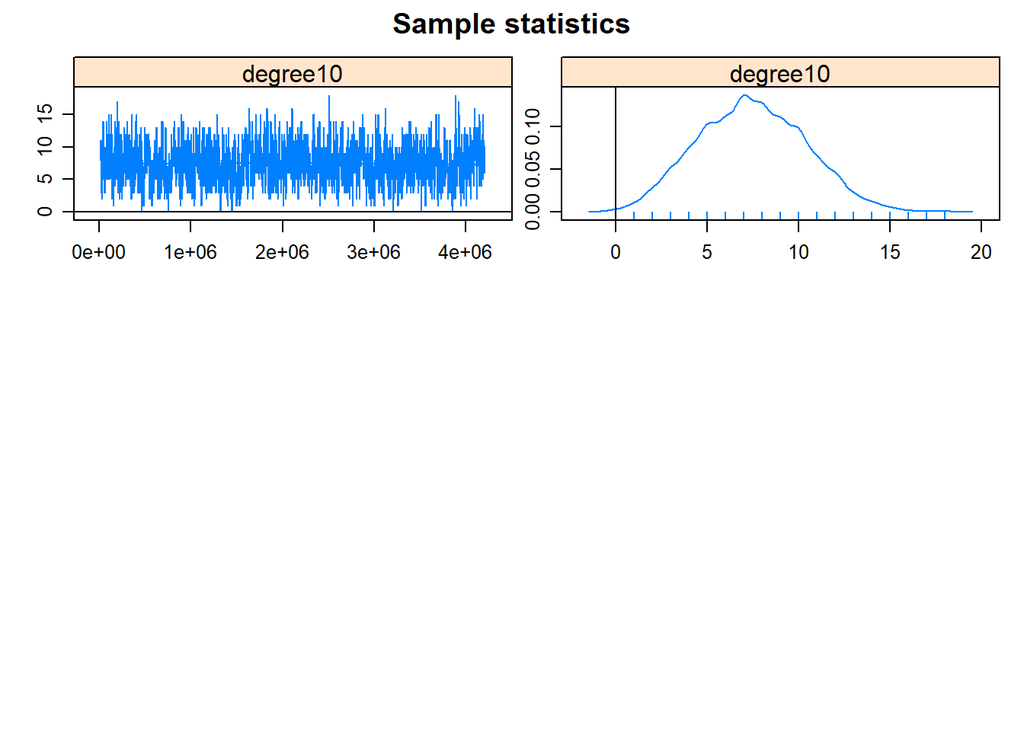

[output not shown]

Let us try something else to see if auto-correlation and Geweke statistics can be improved further.

### Model 2a: Model 2 with Geweke tweaks

```r
#M2b
#gr1.m2b <- ergm(gr1~edges + nodemix('classname',base = 3) + degree(10),
#                control = control.ergm(MCMC.burnin = 100000,MCMC.interval = 10000,MCMC.samplesize = 2048))
summary(gr1.m2b)
```

```
##
## ==========================
## Summary of model fit
## ==========================
##
## Formula:   gr1 ~ edges + nodemix("classname", base = 3) + degree(10)
##
## Iterations:  2 out of 20
##
## Monte Carlo MLE Results:
##                     Estimate Std. Error MCMC % p-value
## edges                 0.8716     0.1148      0  <1e-04 ***
## mix.classname.1A.1A  -0.1112     0.2156      0   0.606
## mix.classname.1A.1B  -3.1606     0.2054      0  <1e-04 ***
## degree10              2.6089     0.6348      0  <1e-04 ***
## ---
## Signif. codes:  0 '***' 0.001 '**' 0.01 '*' 0.05 '.' 0.1 ' ' 1
##
##      Null Deviance: 1434.8  on 1035  degrees of freedom
##  Residual Deviance:  931.9  on 1031  degrees of freedom
##
## AIC: 939.9    BIC: 959.6    (Smaller is better.)
```

#### M2a: GOF

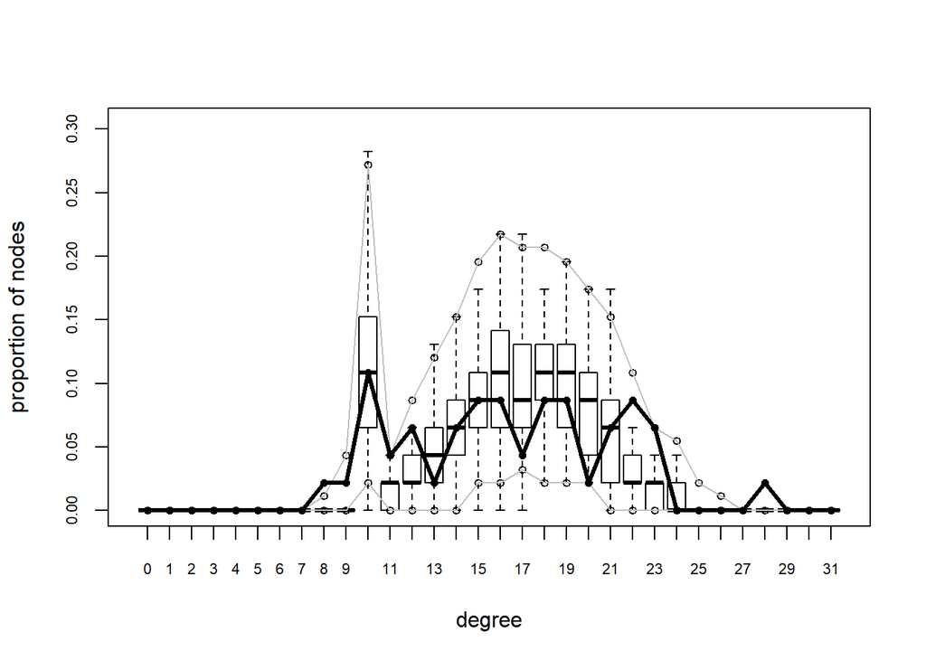

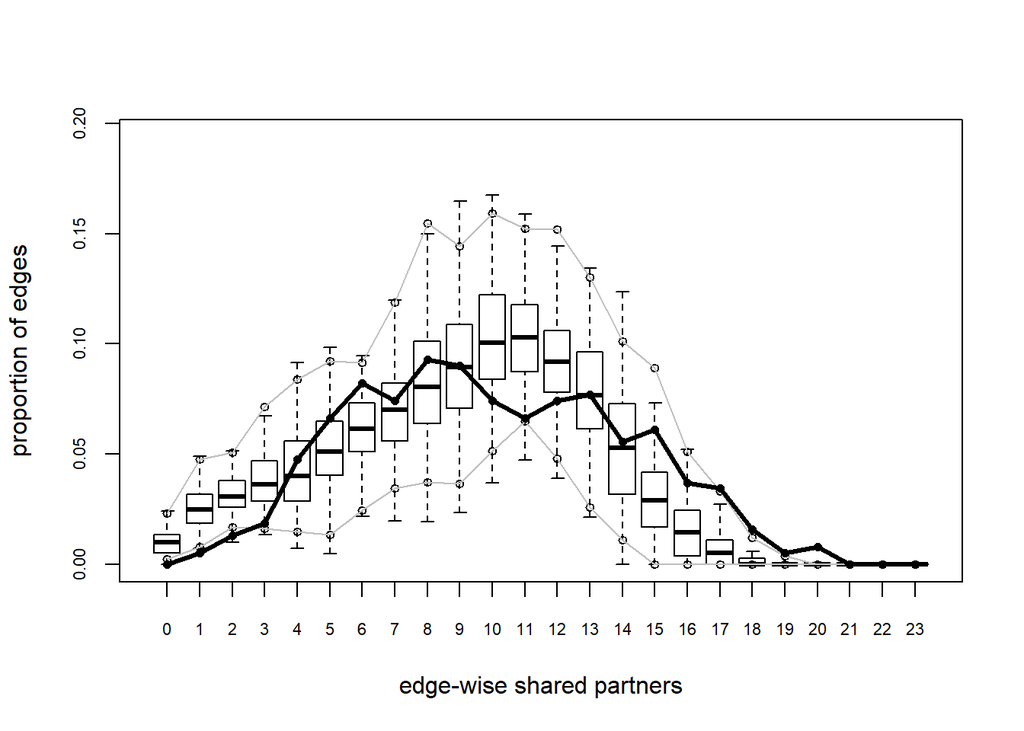

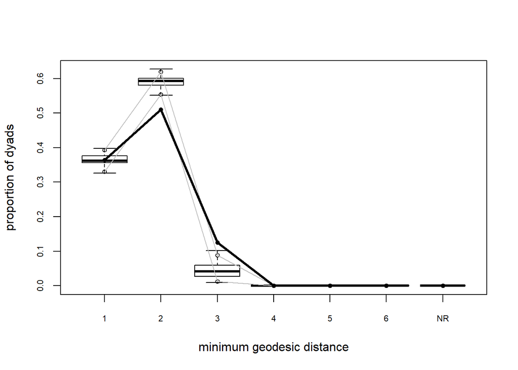

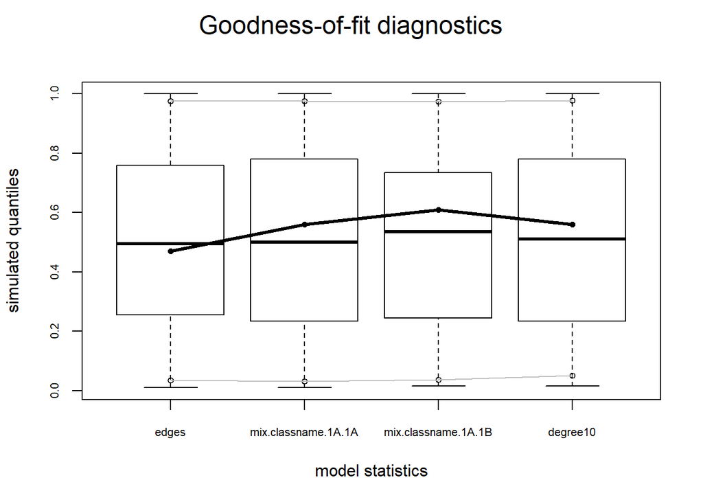

```r
gr1.m2b.gof <- gof(gr1.m2b)
plot(gr1.m2b.gof)
```

#### M2a: Diagnostics

```r
mcmc.diagnostics(gr1.m2b,center = F)
```

```
## Sample statistics summary:
##
## Iterations = 1e+05:82010000
## Thinning interval = 10000
## Number of chains = 1
## Sample size per chain = 8192
##
## 1. Empirical mean and standard deviation for each variable,
##    plus standard error of the mean:
##
##                        Mean     SD Naive SE Time-series SE
## edges               361.906 15.152  0.16741        0.19434
## mix.classname.1A.1A 114.496  8.653  0.09560        0.10573
## mix.classname.1A.1B  38.225  6.474  0.07153        0.07153
## degree10              8.737  2.997  0.03311        0.03579
##
## 2. Quantiles for each variable:
##
##                     2.5% 25% 50% 75% 97.5%
## edges                333 352 362 372   393
## mix.classname.1A.1A   99 108 114 120   133
## mix.classname.1A.1B   26  34  38  43    51
## degree10               3   7   9  11    15
##
##
## Sample statistics cross-correlations:
##                          edges mix.classname.1A.1A mix.classname.1A.1B
## edges                1.0000000           0.6783783           0.5854272
## mix.classname.1A.1A  0.6783783           1.0000000           0.2295265
## mix.classname.1A.1B  0.5854272           0.2295265           1.0000000
## degree10            -0.7223754          -0.8038141          -0.4337937
##                       degree10
## edges               -0.7223754
## mix.classname.1A.1A -0.8038141
## mix.classname.1A.1B -0.4337937
## degree10             1.0000000
##
## Sample statistics auto-correlation:
## Chain 1
##                 edges mix.classname.1A.1A mix.classname.1A.1B    degree10
```

[output cut: 9 more lines]

```
##
## Fraction in 1st window = 0.1
## Fraction in 2nd window = 0.5
##
##               edges mix.classname.1A.1A mix.classname.1A.1B
##             -0.3188              0.9012             -2.0479
##            degree10
##              0.1769
##
## Individual P-values (lower = worse):
##               edges mix.classname.1A.1A mix.classname.1A.1B
##           0.7499031           0.3675046           0.0405695
##            degree10
##           0.8595522
## Joint P-value (lower = worse):  0.1371152 .
```

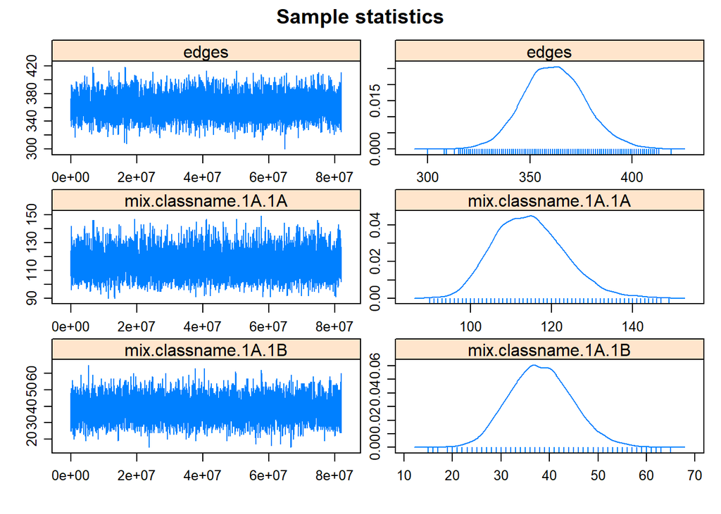

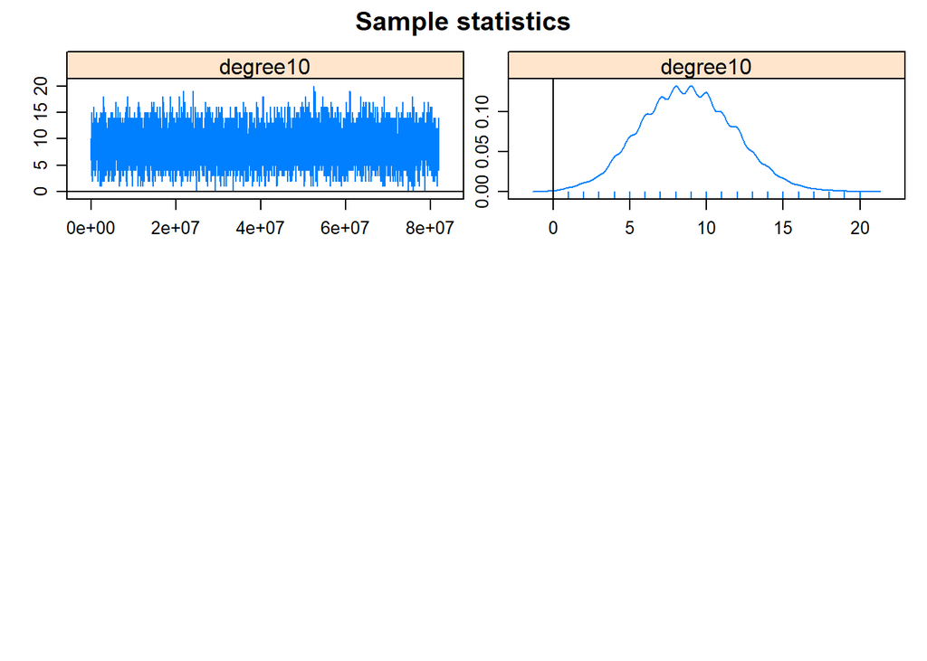

[output not shown]

### Model 3: Differentiating High degree nodes by gender

```r
#M3
#gr1.m3 <- ergm(gr1~edges + nodemix('classname',base = c(1,3)) + degree(10,'gender'))
summary(gr1.m3)
```

```
##
## ==========================
## Summary of model fit
## ==========================
##
## Formula:   gr1 ~ edges + nodemix("classname", base = c(1, 3)) + degree(10,
##     "gender")
##
## Iterations:  4 out of 20
##
## Monte Carlo MLE Results:
##                     Estimate Std. Error MCMC % p-value
## edges                 0.8331     0.1041      0  <1e-04 ***
## mix.classname.1A.1B  -3.1238     0.1834      0  <1e-04 ***
## deg10.genderF         3.3895     0.6921      0  <1e-04 ***
## deg10.genderM         1.8378     1.2049      0   0.128
## ---
## Signif. codes:  0 '***' 0.001 '**' 0.01 '*' 0.05 '.' 0.1 ' ' 1
##
##      Null Deviance: 1435  on 1035  degrees of freedom
##  Residual Deviance:  930  on 1031  degrees of freedom
##
## AIC: 938    BIC: 957.7    (Smaller is better.)
```

#### M3: GOF

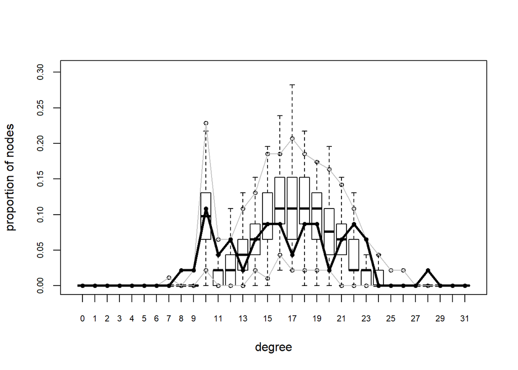

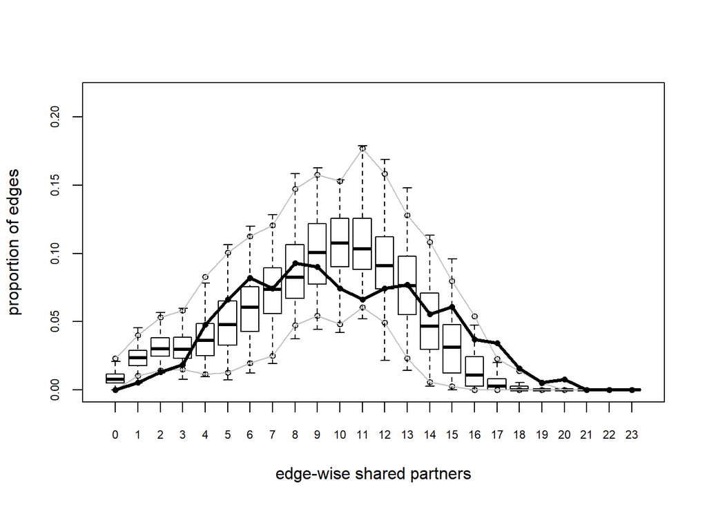

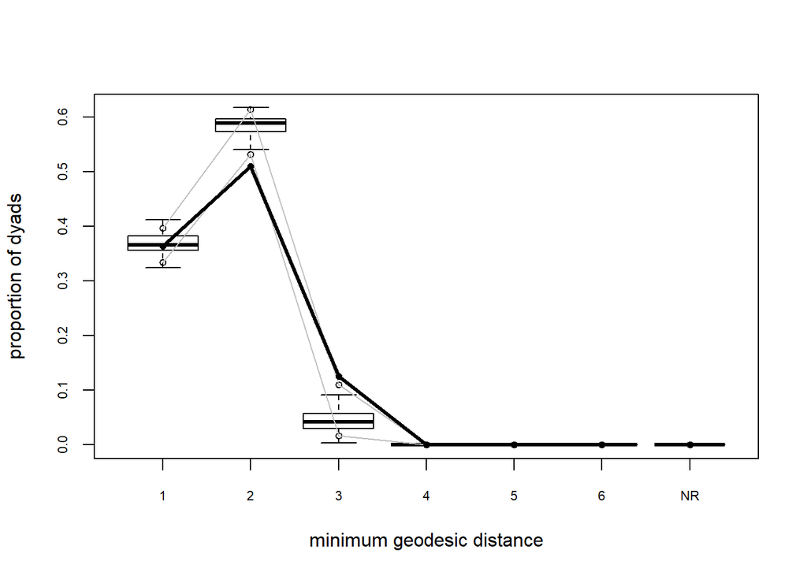

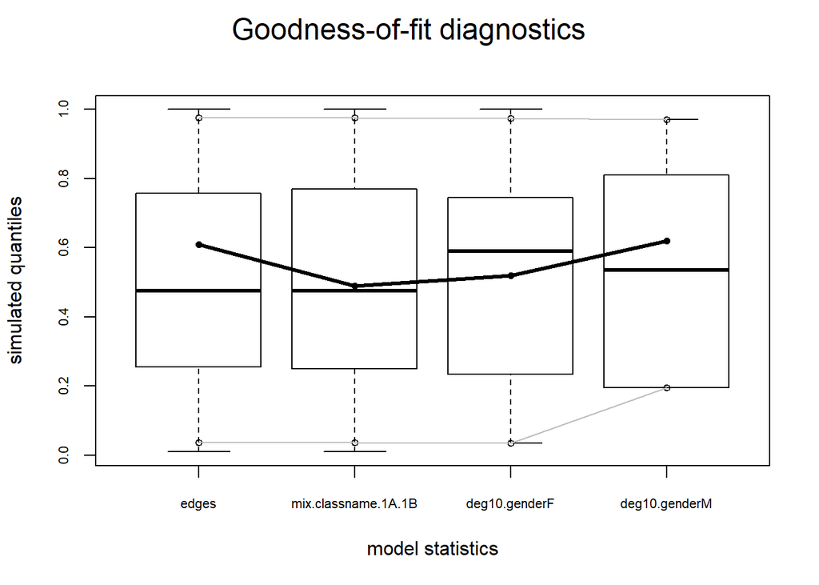

```r
plot(gof(gr1.m3))
```

#### M3: Diagnostics

```r
mcmc.diagnostics(gr1.m3,center = F)
```

```
## Sample statistics summary:
##
## Iterations = 16384:4209664
## Thinning interval = 1024
## Number of chains = 1
## Sample size per chain = 4096
##
## 1. Empirical mean and standard deviation for each variable,
##    plus standard error of the mean:
##
##                        Mean      SD Naive SE Time-series SE
## edges               379.821 16.8995   0.2641        0.71936
## mix.classname.1A.1B  42.260  6.8686   0.1073        0.17758
## deg10.genderF         3.626  2.1053   0.0329        0.10081
## deg10.genderM         0.748  0.9149   0.0143        0.02371
##
## 2. Quantiles for each variable:
##
##                     2.5% 25% 50%   75%  97.5%
## edges                347 368 380 391.2 412.00
## mix.classname.1A.1B   29  37  42  47.0  56.62
## deg10.genderF          0   2   3   5.0   8.00
## deg10.genderM          0   0   1   1.0   3.00
##
##
## Sample statistics cross-correlations:
##                          edges mix.classname.1A.1B deg10.genderF
## edges                1.0000000           0.6041539    -0.7239320
## mix.classname.1A.1B  0.6041539           1.0000000    -0.3899506
## deg10.genderF       -0.7239320          -0.3899506     1.0000000
## deg10.genderM       -0.4185514          -0.2484108     0.2754219
##                     deg10.genderM
## edges                  -0.4185514
## mix.classname.1A.1B    -0.2484108
## deg10.genderF           0.2754219
## deg10.genderM           1.0000000
##
## Sample statistics auto-correlation:
## Chain 1
##              edges mix.classname.1A.1B deg10.genderF deg10.genderM
```

[output cut: 9 more lines]

```
##
## Fraction in 1st window = 0.1
## Fraction in 2nd window = 0.5
##
##               edges mix.classname.1A.1B       deg10.genderF
##             1.01907             2.15581            -0.56175
##       deg10.genderM
##             0.08916
##
## Individual P-values (lower = worse):
##               edges mix.classname.1A.1B       deg10.genderF
##           0.3081712           0.0310986           0.5742858
##       deg10.genderM
##           0.9289544
## Joint P-value (lower = worse):  0.1830272 .
```

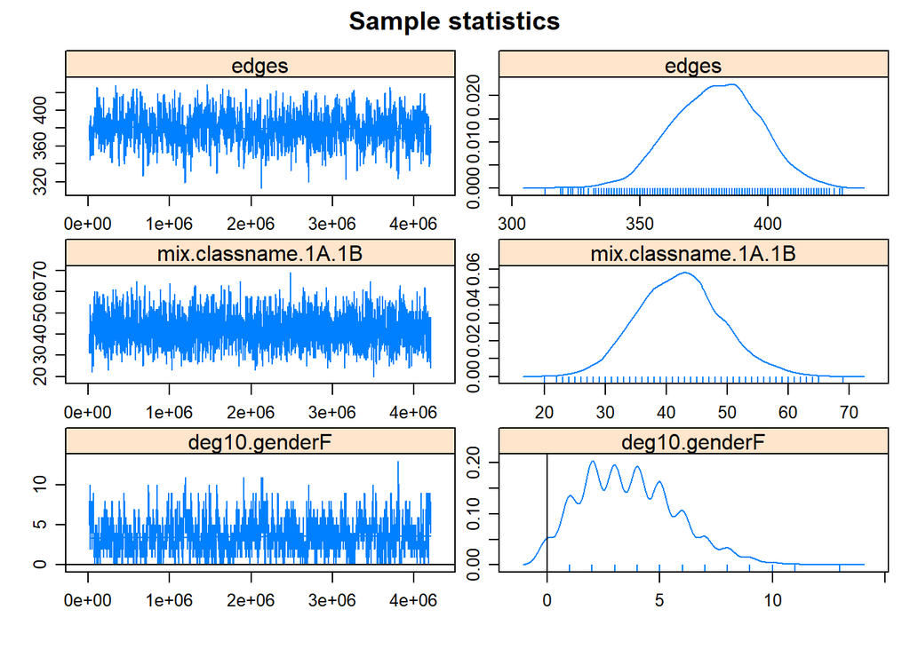

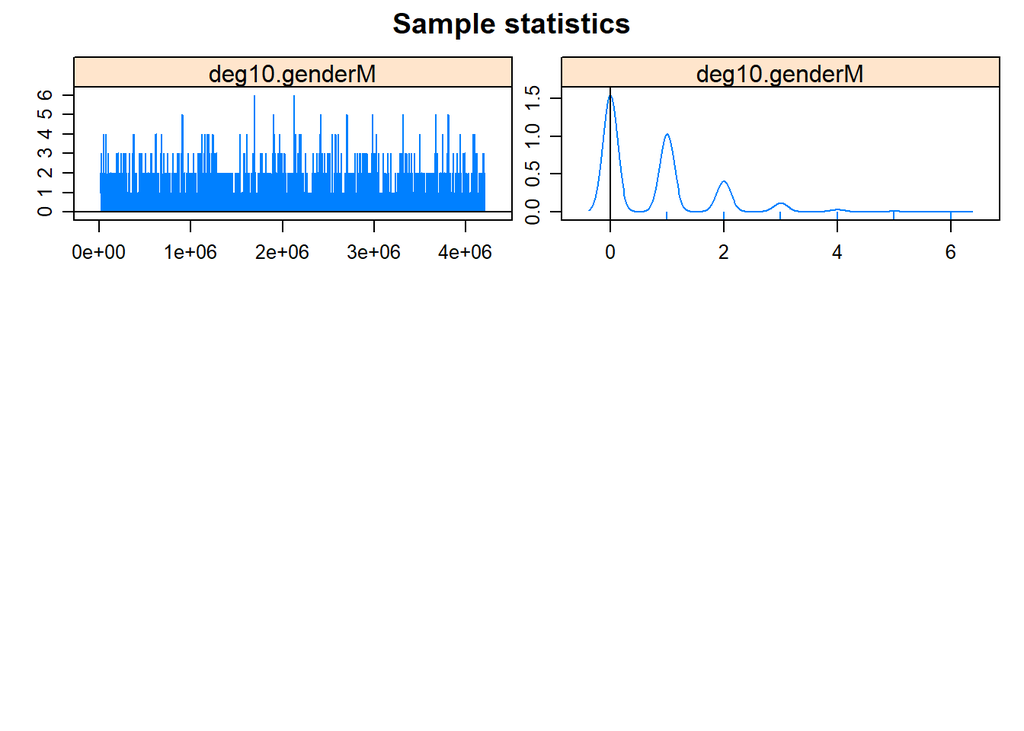

[output not shown]

The Geweke statistics are week in this model. Try changing burnin value

### Model 3a: Model 3 with Gweke tweaks

```r
#M3a
#gr1.m3a <- ergm(gr1~edges + nodemix('classname',base = c(1,3)) + degree(10,'gender'),
#                control = control.ergm(MCMC.burnin = 100000,MCMC.interval = 10000,MCMC.samplesize = 2048))
summary(gr1.m3a)
```

```
##
## ==========================
## Summary of model fit
## ==========================
##
## Formula:   gr1 ~ edges + nodemix("classname", base = c(1, 3)) + degree(10,
##     "gender")
##
## Iterations:  4 out of 20
##
## Monte Carlo MLE Results:
##                     Estimate Std. Error MCMC % p-value
## edges                 0.8268     0.1027      0  <1e-04 ***
## mix.classname.1A.1B  -3.1158     0.1874      0  <1e-04 ***
## deg10.genderF         3.3889     0.6392      0  <1e-04 ***
## deg10.genderM         1.7726     1.1120      0   0.111
## ---
## Signif. codes:  0 '***' 0.001 '**' 0.01 '*' 0.05 '.' 0.1 ' ' 1
##
##      Null Deviance: 1434.8  on 1035  degrees of freedom
##  Residual Deviance:  930.2  on 1031  degrees of freedom
##
## AIC: 938.2    BIC: 958    (Smaller is better.)
```